# HorsePower Predictor App.

2024-06-30

## How does the app work?

This app was built using R to determine the most significant predictors from the mtcars data set, and use them to create a linear regression prediction model that can predict the horsepower of a vehicle, based on it’s displacement, weight, and number of cylinders.

## How to use the app?

To use this app, you need to to input three values :

- The displacement, using a slider.
- The weight, also using a slider.
- The number of cylinders, from a dropdown menu.

## Output and layout explanation :

This app’s front page will have the input section on the sidebar, and two tabs showing the output, and the details of the model itself.

The output you get is the predicted horsepower of the vehicule, and three plots showing the scatter plot of horsepower with each predictor, and on each plot, you will see a red dot representing where the predicted value would fit.

## Final words.

Here is an example of what one of the plots would look like.

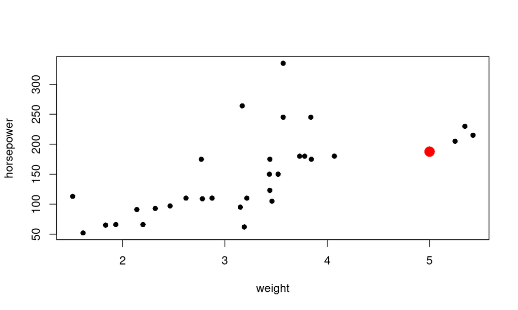

Thank you. Feedback would be appreciated.